# ActSc 632 Assignment 2 Solutions

##### Spring 2023

##### Department of Statistics and Actuarial Science, University of Waterloo

## Question 1

Determine the number of predictors in this data set, and whether they are quantitative of qualita- tive. How many observations are there? How many observations are classiﬁed as a “bad credit”? “good credit”?

```r
library(tree)
library(CASdatasets)
library(pROC)
library(randomForest)
# Load the data
data(credit)

within(credit,{
installment_rate <-factor(installment_rate)
residence_since <- factor(residence_since)
existing_credits <- factor(existing_credits)
num_dependents <- factor(num_dependents)
})
```

[output not shown]

[output cut: 3989 more lines]

```r
# Summary of the data
summary(credit)
```

```
##  checking_status    duration    credit_history    purpose    credit_amount
##  A11:274         Min.   : 4.0   A30: 40        A43    :280   Min.   :  250
##  A12:269         1st Qu.:12.0   A31: 49        A40    :234   1st Qu.: 1366
##  A13: 63         Median :18.0   A32:530        A42    :181   Median : 2320
##  A14:394         Mean   :20.9   A33: 88        A41    :103   Mean   : 3271
##                  3rd Qu.:24.0   A34:293        A49    : 97   3rd Qu.: 3972
##                  Max.   :72.0                  A46    : 50   Max.   :18424
##                                                (Other): 55
##  savings   employment installment_rate personal_status other_parties
##  A61:603   A71: 62    Min.   :1.000    A91: 50         A101:907
##  A62:103   A72:172    1st Qu.:2.000    A92:310         A102: 41
##  A63: 63   A73:339    Median :3.000    A93:548         A103: 52
##  A64: 48   A74:174    Mean   :2.973    A94: 92
##  A65:183   A75:253    3rd Qu.:4.000
##                       Max.   :4.000
##
##  residence_since property_magnitude      age        other_payment_plans
##  Min.   :1.000   A121:282           Min.   :19.00   A141:139
##  1st Qu.:2.000   A122:232           1st Qu.:27.00   A142: 47
##  Median :3.000   A123:332           Median :33.00   A143:814
##  Mean   :2.845   A124:154           Mean   :35.55
##  3rd Qu.:4.000                      3rd Qu.:42.00
##  Max.   :4.000                      Max.   :75.00
##
##  housing    existing_credits   job      num_dependents  telephone
##  A151:179   Min.   :1.000    A171: 22   Min.   :1.000   A191:596
##  A152:713   1st Qu.:1.000    A172:200   1st Qu.:1.000   A192:404
##  A153:108   Median :1.000    A173:630   Median :1.000
##             Mean   :1.407    A174:148   Mean   :1.155
##             3rd Qu.:2.000               3rd Qu.:1.000
##             Max.   :4.000               Max.   :2.000
##
##  foreign_worker     class
##  A201:963       Min.   :0.0
##  A202: 37       1st Qu.:0.0
##                 Median :0.0
##                 Mean   :0.3
##                 3rd Qu.:1.0
##                 Max.   :1.0
##
```

```r
print(c(sum(credit$class == 1),
        sum(credit$class == 0)))
```

```
## [1] 300 700
```

## Question 2

To explore the data further, produce the following plots:

- for each of the predictors age and duration, make a box plot showing the distribution of the observations, separately for the “good” and “bad” observations;
- for the pairs duration & savings and duration & credit history, plot the observations (using duration on the x axis) and use different symbols for the “good” and “bad” observations.

Comments on the plots you obtained.

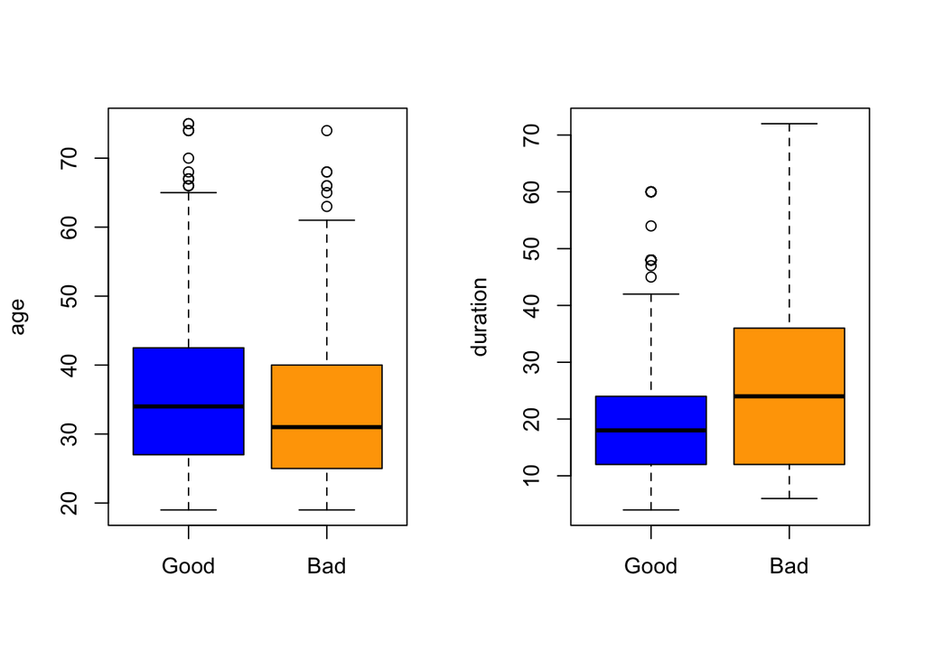

```r
par(mfrow=c(1,2))

# Create a box plot of 'age' for the two classes, displayed inline
boxplot(credit$age[credit$class==0], credit$age[credit$class==1],
        names=c("Good","Bad"), ylab = "age", col=c("blue","orange"))

# Create a box plot of 'duration' for the two classes, displayed inline
boxplot(credit$duration[credit$class==0], credit$duration[credit$class==1],
        names=c("Good","Bad"), ylab = "duration", col=c("blue","orange"))
```

Clearly the bad credit observations seems to have a longer duration, and the distribution of the duration has a larger variance; they also seem to be slightly younger compared to the good credit.

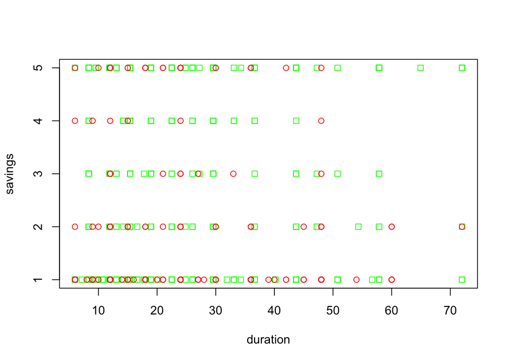

```r
# Set up the plotting area
par(mfrow=c(1,1))

# Subset 'savings' and 'duration' for the two classes
csG<-credit$savings[credit$class==0]
csB<-credit$savings[credit$class==1]
dG<-credit$duration[credit$class==0]
dB<-credit$duration[credit$class==1]

# Plot 'duration' vs 'savings' for the two classes, displayed inline
plot(dG, csG, col=c("green"), pch=0, axes = F, ylab="", xlab="")
par(new=T)
plot(dB, csB, col=c("red"), pch=1, xlab="duration", ylab="savings", axes=T)
```

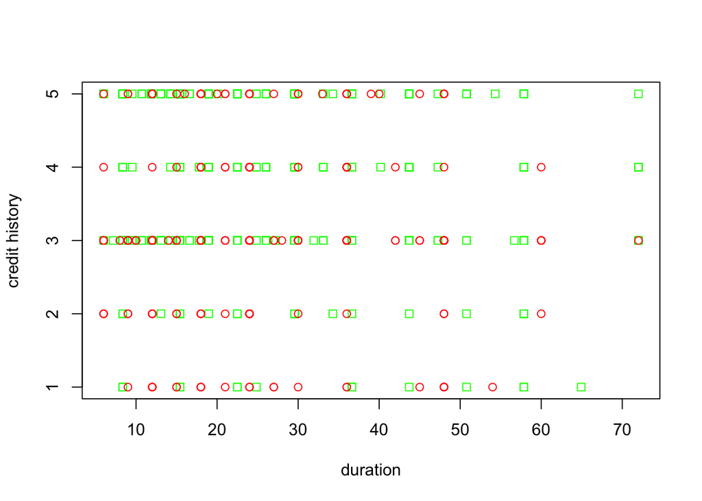

```r
# Set up the plotting area
par(mfrow=c(1,1))

# Subset 'credit_history' for the two classes
chG<-credit$credit_history[credit$class==0]
chB<-credit$credit_history[credit$class==1]

# Plot 'duration' vs 'credit_history' for the two classes, displayed inline
plot(dG, chG, col=c("green"), pch=0, axes = F, ylab="", xlab="")
par(new=T)
plot(dB, chB, col=c("red"), pch=1, xlab="duration", ylab="credit history", axes=T)
```

It is harder to see a clear trend in these two graphs, in that the good and bad credits are not easily classified according to duration for a given level of credit history or savings.

## Question 3

Randomly split your data in 70% of the observations for training and 30% for testing.

```r
set.seed(1)
train <- sample(1:nrow(credit), 0.7 * nrow(credit))

credit$class <- as.factor(credit$class)
```

## Question 4

Simply using recursive binary partitioning, obtain a tree for this classifcation problem.

- How many leaves does your tree have?
- How many factors were used to build this tree?
- What is the deviance for this tree? (If you used something else than the default definition of deviance in R, please specify how is deviance determined).
- Plot the tree you obtained using R. There should be enough information that given an observation, one could determine in which leaf it ends up.
- Use your tree to make predictions for the test data set. Produce the confusion matrix corresponding to your tree and plot the ROC curve.

```r
tree.credit<-tree(class~.,data=credit,subset=train)
summary(tree.credit)
```

```
##
## Classification tree:
## tree(formula = class ~ ., data = credit, subset = train)
## Variables actually used in tree construction:
## [1] "checking_status"    "purpose"            "credit_amount"
## [4] "duration"           "credit_history"     "employment"
## [7] "property_magnitude"
## Number of terminal nodes:  11
## Residual mean deviance:  0.9321 = 642.2 / 689
## Misclassification error rate: 0.2143 = 150 / 700
```

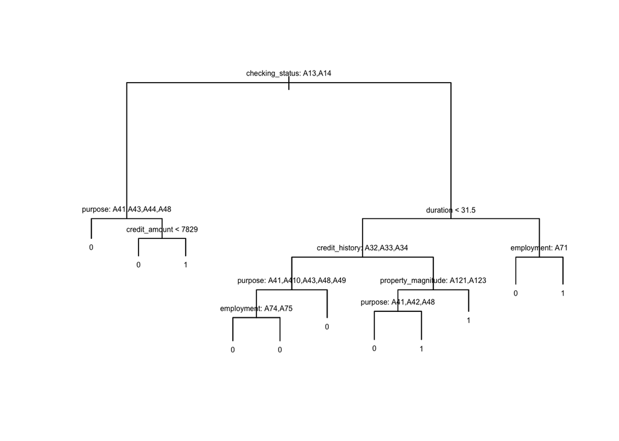

```r
plot(tree.credit)
text(tree.credit,pretty=0,cex=0.5)
```

We recall that the categories listed on a node are those used to determine which observations go in the left child.

```r
pred.tree.cred<-predict(tree.credit,newdata=credit[-train,],type="class")

credit.test<-credit$class[-train]
tree.tab<-table(pred.tree.cred,credit.test)

tree.tab
```

```
##               credit.test
## pred.tree.cred   0   1
##              0 188  64
##              1  20  28
```

```r
print(c("Overall error:", (tree.tab[1,2]+tree.tab[2,1])/sum(tree.tab[,])))
```

```
## [1] "Overall error:" "0.28"
```

```r
print(c("Type I error:", tree.tab[2,1]/sum(tree.tab[,1])))
```

```
## [1] "Type I error:"      "0.0961538461538462"
```

```r
print(c("Type II error:", tree.tab[1,2]/sum(tree.tab[,2])))
```

```
## [1] "Type II error:"    "0.695652173913043"
```

```r
tree.dev.pred <- predict(tree.credit,newdata=credit[-train,],type="tree")

print(c("Deviance:", deviance(tree.dev.pred)))
```

```
## [1] "Deviance:"        "356.791311123743"
```

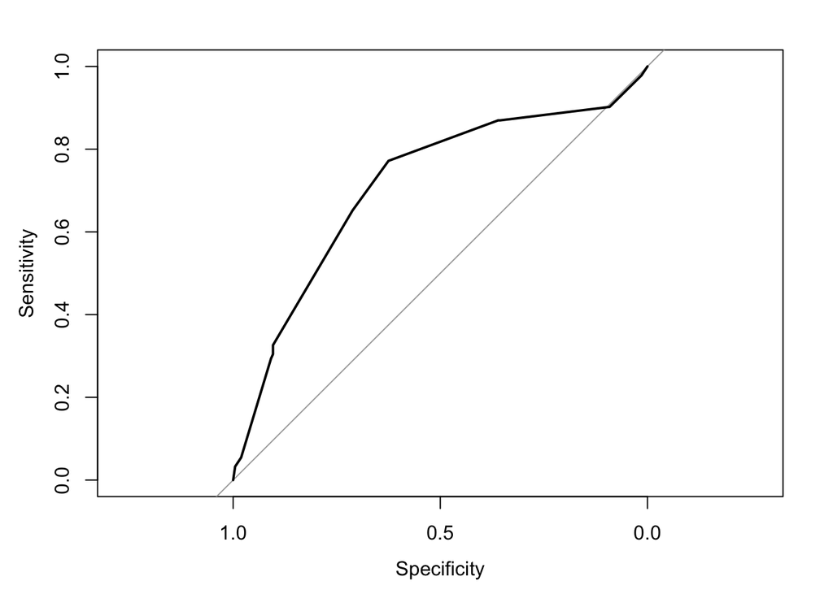

```
##
## Call:
## roc.default(response = credit.test, predictor = predict(tree.credit,     newdata = credit[-train, ], type = "vector")[, 2], plot = TRUE)
##
## Data: predict(tree.credit, newdata = credit[-train, ], type = "vector")[, 2] in 208 controls (credit.test 0) < 92 cases (credit.test 1).
## Area under the curve: 0.7124
```

```r
roc(credit.test,predict(tree.credit,newdata=credit[-train,],type="vector")[,2],plot=TRUE)
```

The ROC curve has AUC of 0.7124.

## Question 5

Now try to use pruning to see if you can improve your results.

```r
cv.credit<-cv.tree(tree.credit,FUN=prune.misclass)
print(cv.credit)
```

```
## $size
## [1] 11  9  7  5  4  1
##
## $dev
## [1] 193 191 186 184 190 208
##
## $k
## [1]     -Inf  0.00000  1.50000  4.00000  6.00000 13.66667
##
## $method
## [1] "misclass"
##
## attr(,"class")
## [1] "prune"         "tree.sequence"
```

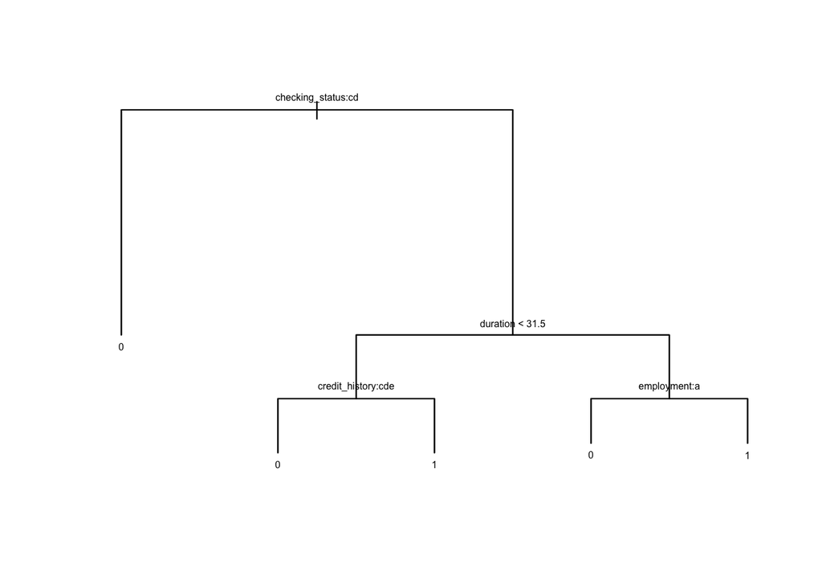

```r
prune.credit<-prune.misclass(tree.credit,best=5)
plot(prune.credit)
text(prune.credit,cex=0.5)
```

```r
summary(prune.credit)
```

```
##
## Classification tree:
## snip.tree(tree = tree.credit, nodes = c(12L, 2L, 13L))
## Variables actually used in tree construction:
## [1] "checking_status" "duration"        "credit_history"  "employment"
## Number of terminal nodes:  5
## Residual mean deviance:  1.036 = 719.9 / 695
## Misclassification error rate: 0.23 = 161 / 700
```

```r
pred.prune.cred<-predict(prune.credit,credit[-train,],type="class")
prune.tab<-table(pred.prune.cred,credit.test)

print(c("Overall error:", (prune.tab[1,2]+prune.tab[2,1])/sum(prune.tab[,])))
```

```
## [1] "Overall error:" "0.27"
```

```r
prtree.dev.pred<- predict(prune.credit,newdata=credit[-train,],type="tree")
print(c("Deviance:", deviance(prtree.dev.pred)))
```

```
## [1] "Deviance:"       "323.24622569088"
```

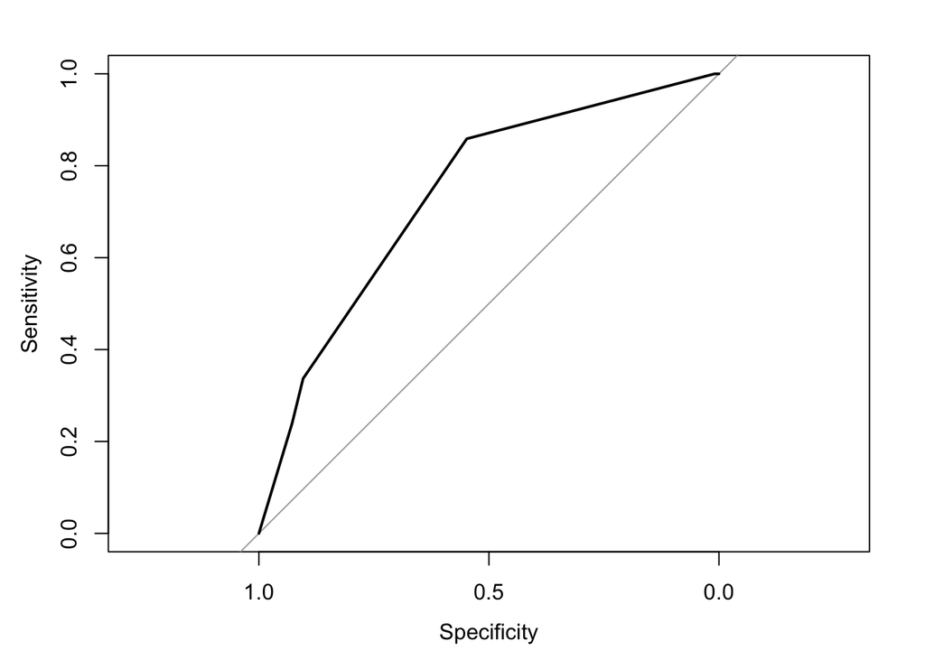

```r
pred.prune.cred.prob<-predict(prune.credit,credit[-train,])
roc.prune.cred<-roc(credit.test,pred.prune.cred.prob[,2],plot=TRUE)
```

```r
print(c("AUC", roc.prune.cred$auc))
```

```
## [1] "AUC"               "0.738268185618729"
```

## Question 6

Now try bagging and random forests to see if you can improve your results.

```r
set.seed(5)
fullbag.credit<-randomForest(class~.,data=credit,subset=train,mtry=20,importance=TRUE)
yhat.bag<-predict(fullbag.credit,newdata=credit[-train,])
bag.tab<-table(yhat.bag,credit.test)

bag.tab
```

```
##         credit.test
## yhat.bag   0   1
##        0 181  49
##        1  27  43
```

```r
rf.credit<-randomForest(class~.,data=credit,subset=train,mtry=20,importance=TRUE)

yhat.rf<-predict(rf.credit,newdata=credit[-train,])
rf.tab<-table(yhat.rf,credit.test)

rf.tab
```

```
##        credit.test
## yhat.rf   0   1
##       0 185  47
##       1  23  45
```

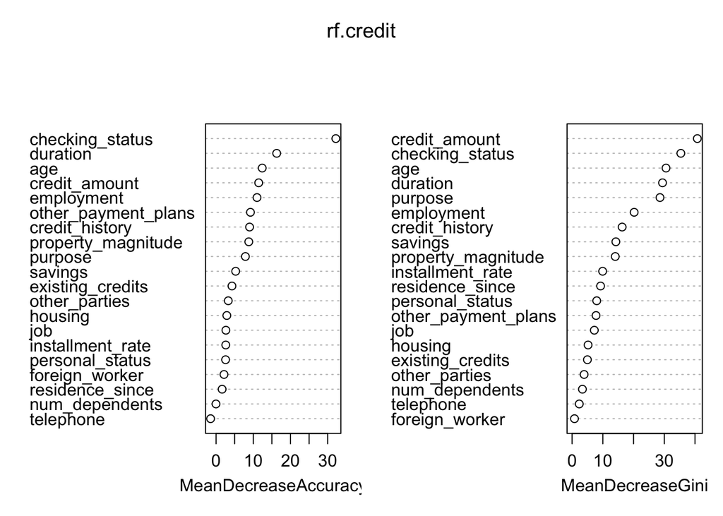

```r
varImpPlot(rf.credit)
```

We see that whether we use the accuracy (prediction error) or Gini index, the predictor checking status seems very important, as well as duration. Other important predictors are credit history and savings, purpose, age and credit amount. These are pretty consistent with the (limited set of ) predictors that were used to construct the pruned tree.

## Question 7

Conclude by making a suggestion as to which of the above methods is the best for this problem.

```r
res.table <- data.frame(matrix(ncol = 4, nrow = 4))

colnames(res.table) <- c("Method", "Overall error", "Type I error", "Type II error")

res.table[1,1] <- "Single Tree"
res.table[1,2] <- (tree.tab[1,2]+tree.tab[2,1])/sum(tree.tab[,])
res.table[1,3] <- tree.tab[2,1]/sum(tree.tab[,1])
res.table[1,4] <- tree.tab[1,2]/sum(tree.tab[,2])

res.table[2,1] <- "Pruned Tree"
res.table[2,2] <- (prune.tab[1,2]+prune.tab[2,1])/sum(prune.tab[,])
res.table[2,3] <- prune.tab[2,1]/sum(prune.tab[,1])
res.table[2,4] <- prune.tab[1,2]/sum(prune.tab[,2])

res.table[3,1] <- "Bagging"
res.table[3,2] <- (bag.tab[1,2]+bag.tab[2,1])/sum(bag.tab[,])
res.table[3,3] <- bag.tab[2,1]/sum(bag.tab[,1])
res.table[3,4] <- bag.tab[1,2]/sum(bag.tab[,2])

res.table[4,1] <- "Random Forest"
res.table[4,2] <- (rf.tab[1,2]+rf.tab[2,1])/sum(rf.tab[,])
res.table[4,3] <- rf.tab[2,1]/sum(rf.tab[,1])
res.table[4,4] <- rf.tab[1,2]/sum(rf.tab[,2])

res.table
```

```
##          Method Overall error Type I error Type II error
## 1   Single Tree     0.2800000   0.09615385     0.6956522
## 2   Pruned Tree     0.2700000   0.09615385     0.6630435
## 3       Bagging     0.2533333   0.12980769     0.5326087
## 4 Random Forest     0.2333333   0.11057692     0.5108696
```